# Effects of time and characteristics of users on Duration of Biker

## by Thomas Tran

## Investigation Overview

In this investigation, I wanted to look at the focus on the record of individual trips with features (ages, time, genders, type of users) which can affect the results of trip.

## Distrubition of User Ages

This is the distrubition of users ages which are from 18 to 60 takes 95% of the users.

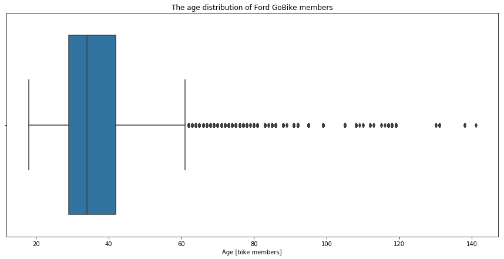

```python
plt.figure(figsize = [15,7])
sb.boxplot(data = df, x = 'users_age')
plt.title("The age distribution of Ford GoBike members")
plt.xlabel("Age [bike members]");
```

## Crowed time in a week and in a day of Bikers.

Number of trips which taken on weekdays is higher than weekends and crowed time is in the morning (around 8 am) and evening (around 5pm). And with the evening trips have longer time than in the morning.

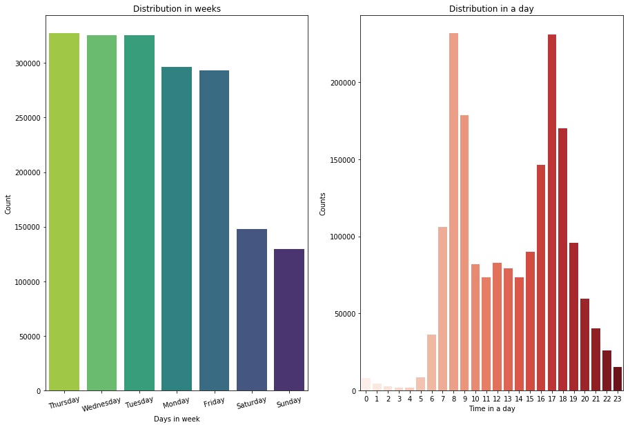

```python
#Create columns of weekday and time in hour of trips taken
df['start_time']=pd.to_datetime(df['start_time'])
df['start_time_weekday'] = df['start_time'].dt.weekday_name
df['start_time_hour'] = df['start_time'].dt.hour

#Set order of values
days_count = df.start_time_weekday.value_counts()
days_order = days_count.index
#Plot distribution of weekday.
plt.figure(figsize =[15,10])
plt.subplot(121)
sb.countplot(data= df, x = 'start_time_weekday', palette = 'viridis_r', order = days_order);
plt.title('Distribution in weeks')
plt.xlabel('Days in week')
plt.xticks(rotation = 15)
plt.ylabel('Count');

plt.subplot(122)
sb.countplot(data = df, x = 'start_time_hour', palette = 'Reds');
plt.title('Distribution in a day')
plt.xlabel('Time in a day')
plt.ylabel('Counts');
```

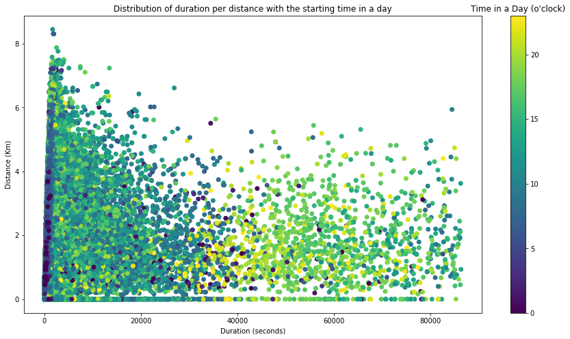

```python
plt.figure(figsize = [15,8])
plt.scatter(data = df, x = 'duration_sec', y = 'distance_estimates', c = 'start_time_hour')
plt.title('Distribution of duration per distance with the starting time in a day')
plt.xlabel('Duration (seconds)')
plt.ylabel('Distance (Km)')
clb = plt.colorbar()
clb.ax.set_title("Time in a Day (o'clock)");
```

## Rate of genders, types and the average duration of them.

Although the rate of Males is higher than Females and Subcribers is higher than Customer, but the result of duration is so surprisingly with different effect.

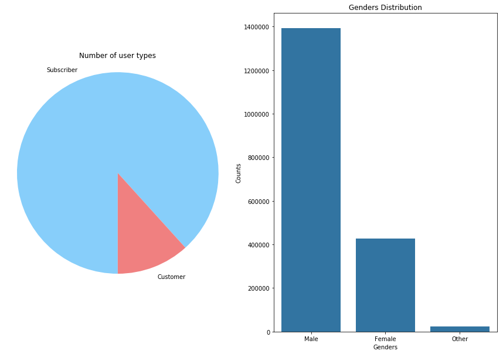

```python
plt.figure(figsize =[15,10])
plt.subplot(121)
sorted_counts = df['user_type'].value_counts()
plt.pie(sorted_counts, labels = sorted_counts.index, startangle = -90, counterclock = False, colors = ['lightskyblue', 'lightcoral']);
plt.axis('square')
plt.title('Number of user types');

plt.subplot(122)
default_color = sb.color_palette()[0]
sb.countplot(data = df, x = 'member_gender', color = default_color);
plt.xlabel('Genders')
plt.ylabel('Counts')
plt.title('Genders Distribution');
```

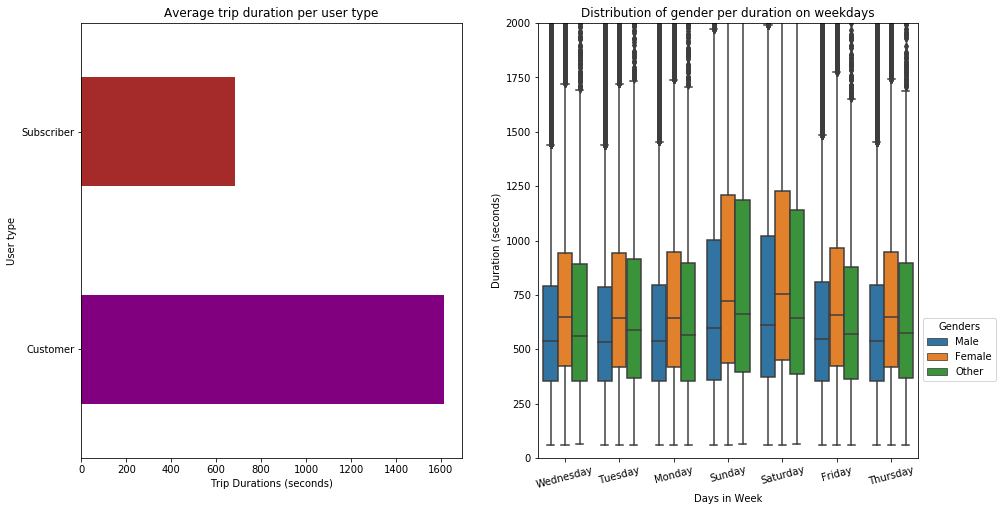

```python
plt.figure(figsize =[15,10])
plt.subplot(121)
colors = ['purple', 'Brown']
ax = df.groupby('user_type')['duration_sec'].mean().plot(kind='barh', color = colors, figsize=(15,8))
ax.set_title('Average trip duration per user type')
ax.set_ylabel('User type')
ax.set_xlabel('Trip Durations (seconds)');

plt.subplot(122)
sb.boxplot(data = df, x = 'start_time_weekday', y = 'duration_sec', hue = 'member_gender');
plt.xticks(rotation = 15);
plt.title('Distribution of gender per duration on weekdays')
plt.ylim(0,2000)
plt.xlabel('Days in Week')
plt.ylabel('Duration (seconds)')
plt.legend(title = 'Genders',loc = 6, bbox_to_anchor = (1, 0.25));
```